# Figure 2 Diversity

Talia_Karasov

5/9/2019

# The relationship between load and diversity and some statistics about differences between populations

The goal of this script is to look at the relationship between load and diversity

Let’s look at the relationship in Germany:

First load the bacteria

and find samples that have variance in all three:

```r
g_s_otus_filter_bacteria = g_s_tot_bacteria[[1]]

g_s_country = g_s_tot_bacteria[[2]]

g_s_pop_bacteria = g_s_tot_bacteria[[3]]

g_s_load_bacteria = g_s_tot_bacteria[[4]]
```

### How is load associated with Shannon Diversity

#### Calculate diversity for bacteria

Is the pattern driven by an artifact (lower bacterial sequencing = lower diversity)?

```r
pdf("~/Dropbox/controlled_metagenomics/results_figures/shannon_load_cov.pdf", family = "ArialMT", useDingbats = FALSE)

p1 = qplot(log10(total_bac_reads), shannon, data = div_tog_bac) +
  theme_light() +
  xlab("")
  #xlab(expression(paste('log'[10],"(Bacterial Reads)", sep=""))) +
  ylab("Shannon's H'")
```

```
## $y
## [1] "Shannon's H'"
##
## attr(,"class")
## [1] "labels"
```

```r
p2 = qplot(log10(total_bac_reads), richness, data = div_tog_bac) +
  theme_light() +
  xlab(expression(paste('log'[10],"(Bacterial Reads)", sep=""))) +
  ylab("Species Richness")

plot_grid(p1, p2, ncol=1, align = "v")

dev.off()
```

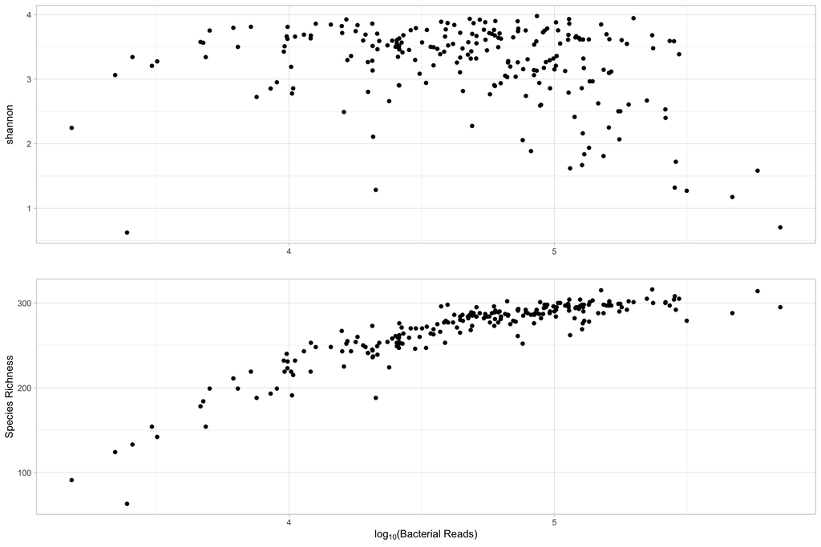

```r
plot_grid(p1, p2, ncol=1, align = "v")
```

There’s clearly a relationship between species richness and both load and bacterial reads total. So we must figure out if this is the result of sampling depth or some real phenomenon.

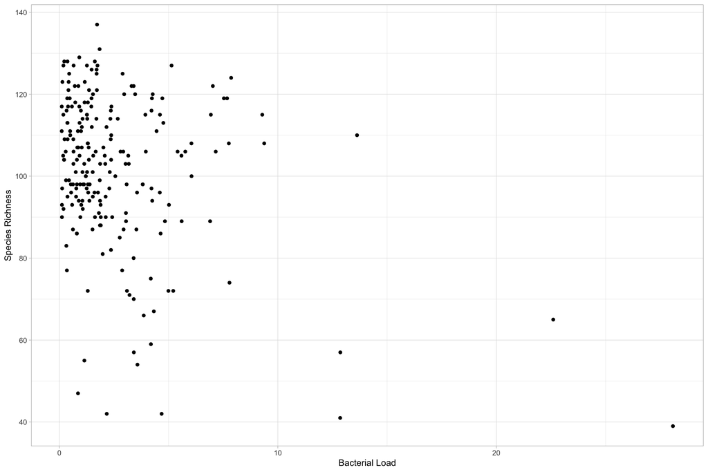

```r
#randomly sample 1000 reads per row without replacement
rare = vegan::rrarefy(tot, 1000)

div_rare = bind_cols(richness = specnumber(rare), rows = names(max_tax_bac), load_bac = g_s_load_bacteria, shannon = shannon_div)

qplot(data = div_rare, x = load_bac, y = richness) + xlab("Bacterial Load") + ylab("Species Richness") + theme_light()
```

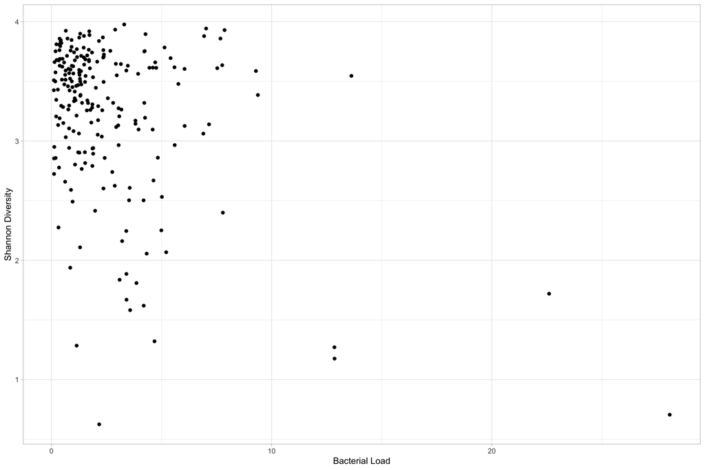

```r
qplot(data = div_rare, x = load_bac, y = shannon) + xlab("Bacterial Load") + ylab("Shannon Diversity") + theme_light()
```

But if the abundance of Pseudomonas were to reduce the abundance of other microbes we would see a negative relationships in the ratios to plant

```r
g_s_otus_bac <- g_s_bacteria[,which(colnames(g_s_bacteria)%ni%c("population", "country", "load"))]

otu_sort = g_s_otus_bac[,order(colSums(g_s_otus_bac), decreasing = T)][,c(1:20)]

cor_mat = rcorr(as.matrix(otu_sort))

p_mat = cor_mat$P

p_mat = matrix(p.adjust(p_mat, method = "BH"), nrow = 20, ncol = 20)

pdf("~/Dropbox/controlled_metagenomics/results_figures/bac_corr_mat.pdf", family = "ArialMT", useDingbats = FALSE, height = 6, width = 7 )

corrplot(cor_mat$r, pch = 20, type = "upper", method = "circle", p.mat = p_mat, sig.level = 0.05, insig = "blank",col = brewer.pal(n = 9, name = "PuOr"), tl.cex = 0.5, cl.align.text = 'c', cl.cex = 0.7 )

dev.off()
```

### Now let’s build models to test the relationship between load and other variables

```r
div_tog = div_tog_bac

load_max_bac = betareg(max_tax ~ load_bac, data = div_tog_bac)

load_shan_bac = lm(shannon ~ load_bac, data = div_tog_bac)

summary(load_max_bac)
```

```
##
## Call:
## betareg(formula = max_tax ~ load_bac, data = div_tog_bac)
##
## Standardized weighted residuals 2:
##     Min      1Q  Median      3Q     Max
## -1.9638 -0.6472 -0.2080  0.5539  4.0158
##
## Coefficients (mean model with logit link):
##             Estimate Std. Error z value Pr(>|z|)
## (Intercept) -1.20147    0.06454 -18.615  < 2e-16 ***
## load_bac     0.08104    0.01475   5.495  3.9e-08 ***
##
## Phi coefficients (precision model with identity link):
##       Estimate Std. Error z value Pr(>|z|)
## (phi)   8.3647     0.7715   10.84   <2e-16 ***
## ---
## Signif. codes:  0 '***' 0.001 '**' 0.01 '*' 0.05 '.' 0.1 ' ' 1
##
## Type of estimator: ML (maximum likelihood)
## Log-likelihood: 127.5 on 3 Df
## Pseudo R-squared: 0.1325
## Number of iterations: 12 (BFGS) + 1 (Fisher scoring)
```

```r
cor.test(div_tog_bac$max_tax, div_tog_bac$load_bac, method = "pearson")
```

```
##
##  Pearson's product-moment correlation
##
## data:  div_tog_bac$max_tax and div_tog_bac$load_bac
## t = 6.0424, df = 216, p-value = 6.574e-09
## alternative hypothesis: true correlation is not equal to 0
## 95 percent confidence interval:
##  0.260537 0.488449
## sample estimates:
##       cor
## 0.3802509
```

pull colors for points and recode max_tax_names

```r
out_bacteria = meta_table("bacteria")

families1 = sort(unique(out_bacteria$germany$Family))

colors_families1 = hue1_12[1:length(families1)]

color_hash = data.frame(key=families1, value=colors_families1)

for(i in 1:length(max_tax_names)){
  if(max_tax_names[i] %ni% families1){
    print(i)
    max_tax_names[i] = "Other"
  }
}
```

```
## [1] 18
## [1] 36
## [1] 44
## [1] 62
## [1] 64
## [1] 69
## [1] 76
## [1] 119
## [1] 138
## [1] 147
## [1] 155
## [1] 158
## [1] 160
## [1] 194
## [1] 196
```

```r
re_max = color_hash[match(max_tax_names, color_hash$key),"value"]
```

### Now we can build the plots

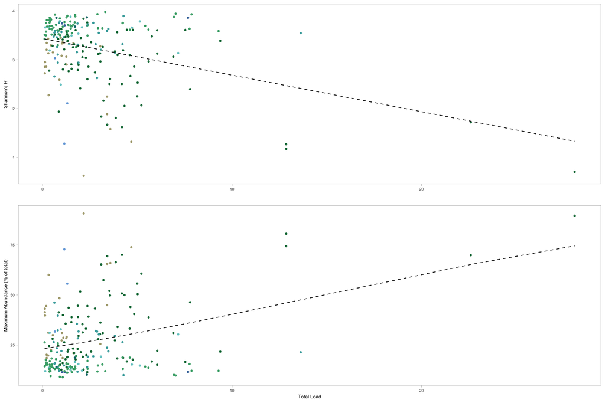

```r
J_plot_bac<-ggplot(data=div_tog, aes(x=log10(load_bac), y=J)) +
  geom_point(pch=20) +
  geom_smooth(method='lm', color='red', level=0) +
  theme_light() +
  theme( panel.grid.major = element_blank(), panel.grid.minor = element_blank()) +
  xlab(expression(paste(' Load (log'[10],"(Total Microb. Cov./Plant Cov.))", sep=""))) +
  ylab("Evenness (Pielou's J)")

Shannon_div_plot_bac<-ggplot(data=div_tog, aes(x=load_bac, y=shannon)) +
  geom_point(pch=20, color = re_max) +
  #geom_smooth(method='lm', colour='gray10', level=0, linetype = "dashed") +
  geom_line(aes(y = predict(load_shan_bac, div_tog_bac)), colour = "gray10", linetype = "dashed") +
  theme_light() +
  theme(panel.grid.major = element_blank(),
        panel.grid.minor = element_blank(),
        text = element_text(size=7)) +
  xlab("Total Load") +
  #xlab(expression(paste(' Load (log'[10],"(Total Microb. Cov./Plant Cov.))", sep=""))) +
  ylab("Shannon's H'")

max_plot_bac<-ggplot(data=div_tog, aes(x= load_bac, y=max_tax_bac)) +
  geom_point(pch=20, color = re_max) +
  scale_color_manual(values = hue1_12) +
  #geom_smooth(method='lm', color='red', level=0) +
  geom_line(aes(y = predict(load_max_bac, div_tog_bac)), colour = "gray10", linetype = "dashed") +
  theme_light() +
  theme(panel.grid.major = element_blank(),
        panel.grid.minor = element_blank(),
        text = element_text(size=7)) +
  xlab("Total Load") +
  #xlab(expression(paste(' Load (log'[10],"(Total Microb. Cov./Plant Cov.))", sep=""))) +
  ylab("Maximum Abundance (% of total)") +
  scale_y_continuous(labels = function(x) x * 100)
  #geom_text(aes(label=ifelse(load_bac>10,as.character(max_tax_names),'')),position=position_jitter(width=.1,height=.1))


plot_grid(Shannon_div_plot_bac + xlab(""), max_plot_bac, ncol=1, align = "v")
```

And plot to file

```r
pdf(paste(paste("~/Dropbox/controlled_metagenomics/results_figures/div_load", concat_name, sep=""),".pdf",sep=""), family = "ArialMT", useDingbats = FALSE, width = 4.7, height = 4.6)

plot_grid(Shannon_div_plot_bac + xlab(""), max_plot_bac, ncol=1, align = "v")

dev.off()
```

### Does load affect the overall evenness of the sample?

```r
cor.test(g_s_load_bacteria, J)
```

```
##
##  Pearson's product-moment correlation
##
## data:  g_s_load_bacteria and J
## t = -6.7555, df = 216, p-value = 1.3e-10
## alternative hypothesis: true correlation is not equal to 0
## 95 percent confidence interval:
##  -0.5215796 -0.3015014
## sample estimates:
##        cor
## -0.4176472
```

```r
cor.test(g_s_load_bacteria, shannon_div)
```

```
##
##  Pearson's product-moment correlation
##
## data:  g_s_load_bacteria and shannon_div
## t = -5.9679, df = 216, p-value = 9.741e-09
## alternative hypothesis: true correlation is not equal to 0
## 95 percent confidence interval:
##  -0.4848697 -0.2561599
## sample estimates:
##        cor
## -0.3762317
```

```r
cor.test(g_s_load_bacteria, max_tax_bac)
```

```
##
##  Pearson's product-moment correlation
##
## data:  g_s_load_bacteria and max_tax_bac
## t = 6.0424, df = 216, p-value = 6.574e-09
## alternative hypothesis: true correlation is not equal to 0
## 95 percent confidence interval:
##  0.260537 0.488449
## sample estimates:
##       cor
## 0.3802509
```

### Are these trends driven by the outliers?

```r
med_load = div_tog_bac %>% filter(load_bac<10)

cor.test(med_load$load_bac, med_load$shannon)
```

```
##
##  Pearson's product-moment correlation
##
## data:  med_load$load_bac and med_load$shannon
## t = -1.8369, df = 211, p-value = 0.06764
## alternative hypothesis: true correlation is not equal to 0
## 95 percent confidence interval:
##  -0.25557746  0.00912944
## sample estimates:
##        cor
## -0.1254562
```

```r
cor.test(med_load$load_bac, med_load$simpson)
```

```
##
##  Pearson's product-moment correlation
##
## data:  med_load$load_bac and med_load$simpson
## t = -2.0394, df = 211, p-value = 0.04266
## alternative hypothesis: true correlation is not equal to 0
## 95 percent confidence interval:
##  -0.268445851 -0.004687461
## sample estimates:
##        cor
## -0.1390315
```

```r
cor.test(med_load$load_bac, med_load$max_tax)
```

```
##
##  Pearson's product-moment correlation
##
## data:  med_load$load_bac and med_load$max_tax
## t = 2.0717, df = 211, p-value = 0.03951
## alternative hypothesis: true correlation is not equal to 0
## 95 percent confidence interval:
##  0.006891377 0.270489803
## sample estimates:
##       cor
## 0.1411922
```

# Average genome coverage:

### Basic statistics on the mean and median abundances of microbes.

```
## [1] 1.584908
```

```
## [1] 2.531323
```

```
## [1] 9.913433
```

```r
bac_all = process_gs_keep_all(g_s_bacteria)

fung_all = process_gs_keep_all(g_s_fungi)

oom_all = process_gs_keep_all(g_s_oom)

g_s_country = bac_all[[2]]

g_s_pop = bac_all[[3]]

g_s_load_bacteria = bac_all[[4]]

g_s_load_fungi = fung_all[[4]]

g_s_load_oom = oom_all[[4]]
```

g_s_all_info = bind_cols(country = g_s_country, pop = g_s_pop, load_bac = g_s_load_bacteria, load_fungi = g_s_load_fungi, load_oom = g_s_load_oom)

g_s_all_info = g_s_all_info[which(is.na(g_s_all_info$pop)==FALSE),]

wilcox.test(g_s_all_info[which(g_s_all_info$country == “germany”),]$load_bac, g_s_all_info[which(g_s_all_info$country == “Sweden”),]$load_bac)

wilcox.test(g_s_all_info[which(g_s_all_info$country == “germany”),]$load_fungi, g_s_all_info[which(g_s_all_info$country == “Sweden”),]$load_fungi)